# US Accident Dataset: Apurva Shekhar, ashekhar@scu.edu

### The dataset comprise of 2.25 million records of accidents on road across all

### state in the USA. I have tried to find answers for the following questions -

### 1. Accidents trend over Years

### 2. Accident By Weekday

### 3. Top States By Accident

### 4. Top 10 states with most severe accidents

### 5. Accidents by Severity

### 6. Number of Accidents By Time of Day In Caifornia

### 7. Dominant Factors For Accidents In Each County

```r
# Load dataset
# Download - https://www.kaggle.com/sobhanmoosavi/us-accidents
setwd("/Users/apurvashekhar/Desktop/SCU/Quarter_1/R")
accident_data <- read.csv("US_Accidents_May19.csv", stringsAsFactors = FALSE)

# Required libraries.
if (!require(ggplot2)) install.packages("ggplot2")
if (!require(stringr)) install.packages("stringr")
library(dplyr)
library(ggplot2)
library(stringr)
```

### Parsed WeatherTimestamp in accident data to convert it to POSIXct time.

### Also, extracted date, day of week, hour, month and year as seperate columns from

### ParsedDateTime column for future use.

```r
accident_data$ParsedDateTime <- as.POSIXct(strptime(accident_data$Weather_Timestamp, format="%Y-%m-%d %H:%M:%S"))
accident_data$Date <- format(accident_data$ParsedDateTime, format="%Y-%m-%d")
accident_data$Day <- format(accident_data$ParsedDateTime, format="%A")
accident_data$Hour <- format(accident_data$ParsedDateTime, format="%H")
accident_data$Month <- format(accident_data$ParsedDateTime, format="%m")
accident_data$Year <- format(accident_data$ParsedDateTime, format="%Y")
```

### Parsed boolean attribute columns as boolean values.

```r
accident_data$Amenity_bool = as.logical(accident_data$Amenity)
accident_data$Bump_bool = as.logical(accident_data$Bump)
accident_data$Crossing_bool = as.logical(accident_data$Crossing)
accident_data$GiveWay_bool = as.logical(accident_data$Give_Way)
accident_data$Junction_bool = as.logical(accident_data$Junction)
accident_data$NoExit_bool = as.logical(accident_data$No_Exit)
accident_data$Railway_bool = as.logical(accident_data$Railway)
accident_data$Roundabout_bool = as.logical(accident_data$Roundabout)
accident_data$Station_bool = as.logical(accident_data$Station)
accident_data$Stop_bool = as.logical(accident_data$Stop)
accident_data$TrafficCalming_bool = as.logical(accident_data$Traffic_Calming)
accident_data$TrafficSignal_bool = as.logical(accident_data$Traffic_Signal)
accident_data$TurningLoop_bool = as.logical(accident_data$Turning_Loop)
```

### Accidents trend over Years: This graph shows the trend of accident occurrences.

### The count of accidents is grouped on (Month, Year). The dots in the graph represents

### the months of that particular year.I observed that accident rates increased by approximately

### 1.5x between 2016 and 2017 across all states.

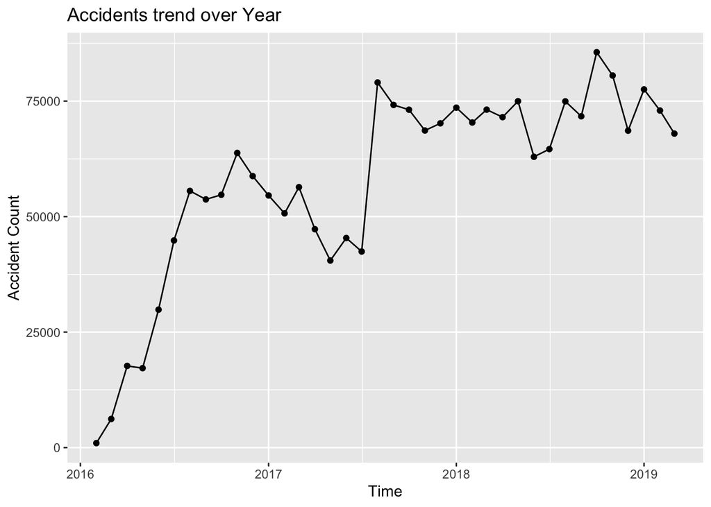

```r
# Grouped by state and counted the number of accidents in each state.
accidents_by_date <- accident_data %>%
  filter(!is.na(ParsedDateTime)) %>%
  group_by(Month = as.POSIXct(paste0(strftime(ParsedDateTime,format="%Y-%m"),"-01")) ) %>%
  summarise(Count = n())
ggplot(data=(accidents_by_date), aes(x = Month, y = Count, group = 1)) +
  geom_line() +
  geom_point() +
  ggtitle("Accidents trend over Year") +
  labs(x= "Time", y = "Accident Count")
```

### Accident By Weekday: The plot counts number of accidents by weekdays.

### The count has been calculated by grouping on Day of Weeks of accident.

### I observed that number of accidents are much less on weekends. This may

### be attributed to fewer number of cars on the roads due to offices being

### closed.

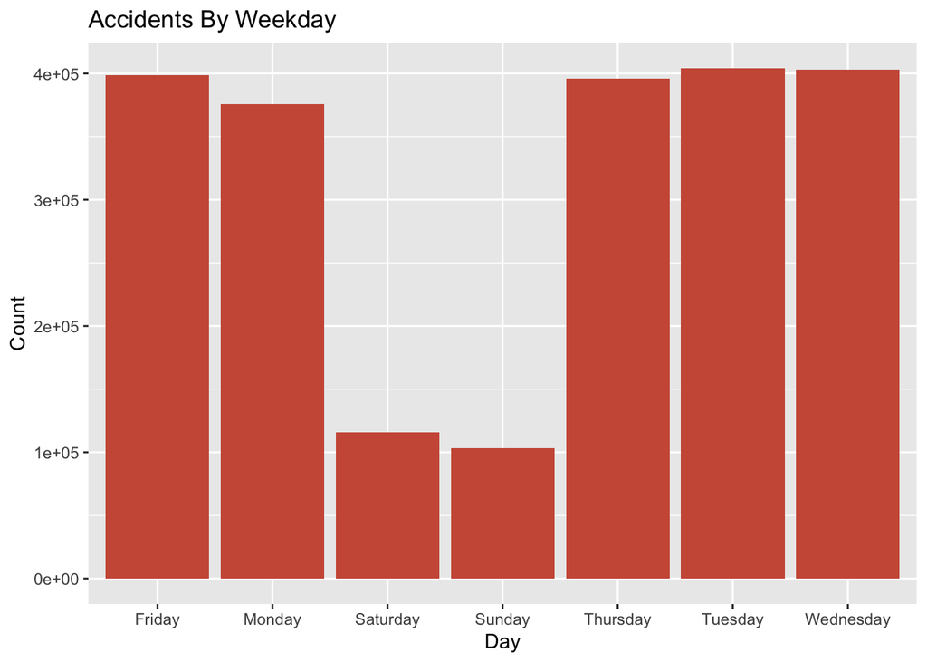

```r
# Grouped by state and counted the number of accidents in each state.
accidents_by_weekday <- accident_data %>%
  filter(!is.na(Day)) %>%
  group_by(Day) %>%
  summarise(Count = n())

# Plot the result.
ggplot(data=(accidents_by_weekday), aes(x = Day, y=Count)) +
  geom_bar(stat = "identity", fill="coral3") +
  ggtitle("Accidents By Weekday")
```

### Top States By Accident: This table and graph shows the top 10 states that have

### the most number of accidents. The table points out that California leads the pack

### with almost double the number of accidents of Texas, that stands second. The interesting

### fact is that even though Texas has higher speed limit i.e 85 mph on highways, it is still

### behind California in the count of accidents. This could be attributed to the fact that

### California has much higher density of cars.

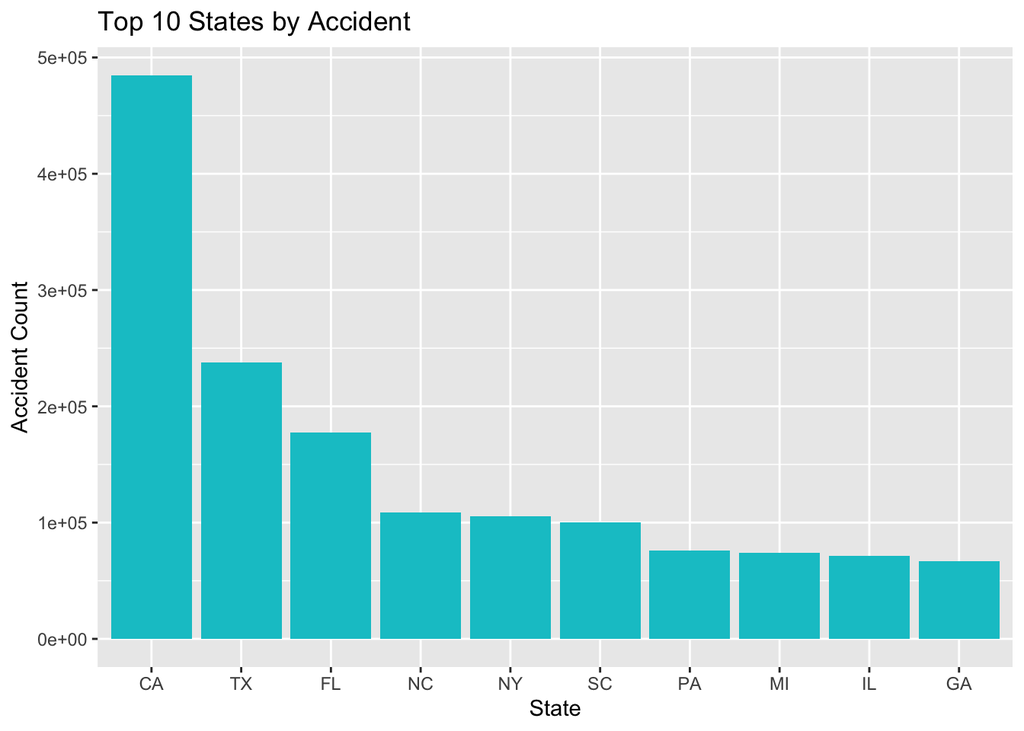

```r
# Grouped by state and counted the number of accidents in each state.
top_states_by_accident <- accident_data %>%
                        group_by(State) %>%
                        summarise(Count = n()) %>%
                        ungroup() %>%
                        arrange(desc(Count)) %>%
                        top_n(10, Count)

# Bar Graph Plot.
ggplot(data=top_states_by_accident, aes(x= reorder(State, -Count), y=Count)) +
  geom_bar(stat = "identity", fill="turquoise3") +
  ggtitle("Top 10 States by Accident") +
  labs(x= "State", y = "Accident Count")
```

```r
# Table View.
top_states_by_accident
```

| State | Count |
| --- | --- |
| CA | 484706 |
| TX | 237637 |
| FL | 177490 |
| NC | 108916 |
| NY | 105523 |
| SC | 99890 |
| PA | 75814 |
| MI | 74045 |
| IL | 71701 |
| GA | 66637 |

### Top 10 states with most severe accidents: The table and plot below shows the top ten

### states that have the most severe accidents. Even though California has almost 3x

### number of accidents than Florida, Florida beats California in occurences of severe

### accidents.

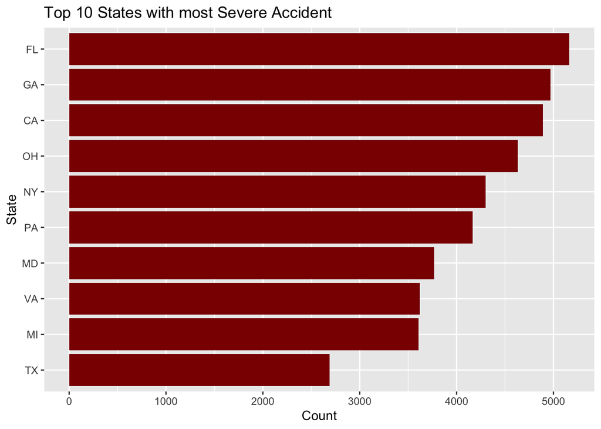

```r
# Filtered the dataset to keep most severe accidents i.e accidents with severity 4.
severe_accidents <- filter(accident_data, Severity == max(Severity))
top_states_by_severe_accidents <- severe_accidents %>%
                        group_by(State) %>%
                        summarise(Count = n()) %>%
                        ungroup() %>%
                        arrange(desc(Count)) %>%
                        top_n(10, Count)

# Bar graph plot.
ggplot(data=top_states_by_severe_accidents,
       aes(x= reorder(State, Count), y=Count)) +
  geom_bar(stat = "identity", fill="darkred") +
  ggtitle("Top 10 States with most Severe Accident") +
  coord_flip() +
  labs(x="State", y= "Count")
```

```r
# Table format.
top_states_by_severe_accidents
```

| State | Count |
| --- | --- |
| FL | 5165 |
| GA | 4968 |
| CA | 4891 |
| OH | 4634 |
| NY | 4300 |
| PA | 4165 |
| MD | 3771 |
| VA | 3621 |
| MI | 3607 |
| TX | 2689 |

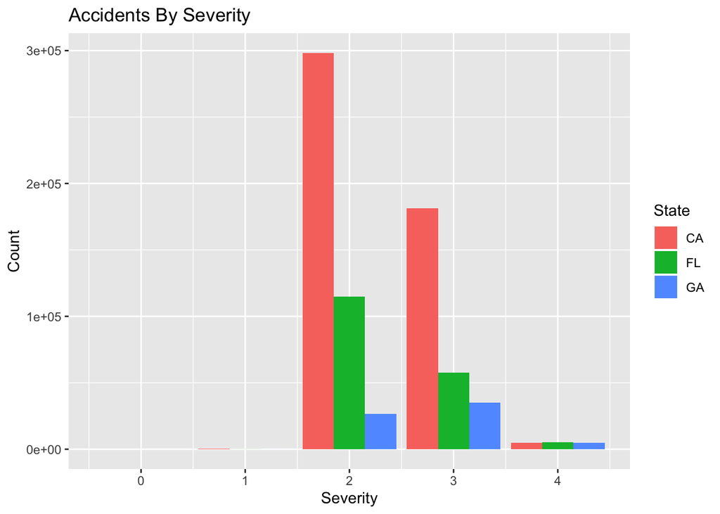

```r
# Group accidents by severity to understand frequency of each severity - Compared three
# categories i.e States.
accidents_by_severity <- accident_data %>%
                        filter(State == "CA" | State == "FL" | State == "GA") %>%
                        group_by(Severity, State) %>%
                        summarise(Count = n());
# Plotting the result.
ggplot(data=accidents_by_severity, aes(x= Severity, y=Count, fill = State)) +
  geom_bar(stat = "identity", position = 'dodge') +
  ggtitle("Accidents By Severity") +
  labs(x="Severity", y= "Count")
```

### Number of Accidents By Time of Day In Caifornia: I dived deep into the state that has the highest

### number of accidents. Dividing the data by the hour of the day, it is indicated that most number of

### accidents occur at 7am and 4pm. This reason behind this trend could be that those hours are

### when people travel to/off from work. Due to higher number of cars, the count of accident soars.

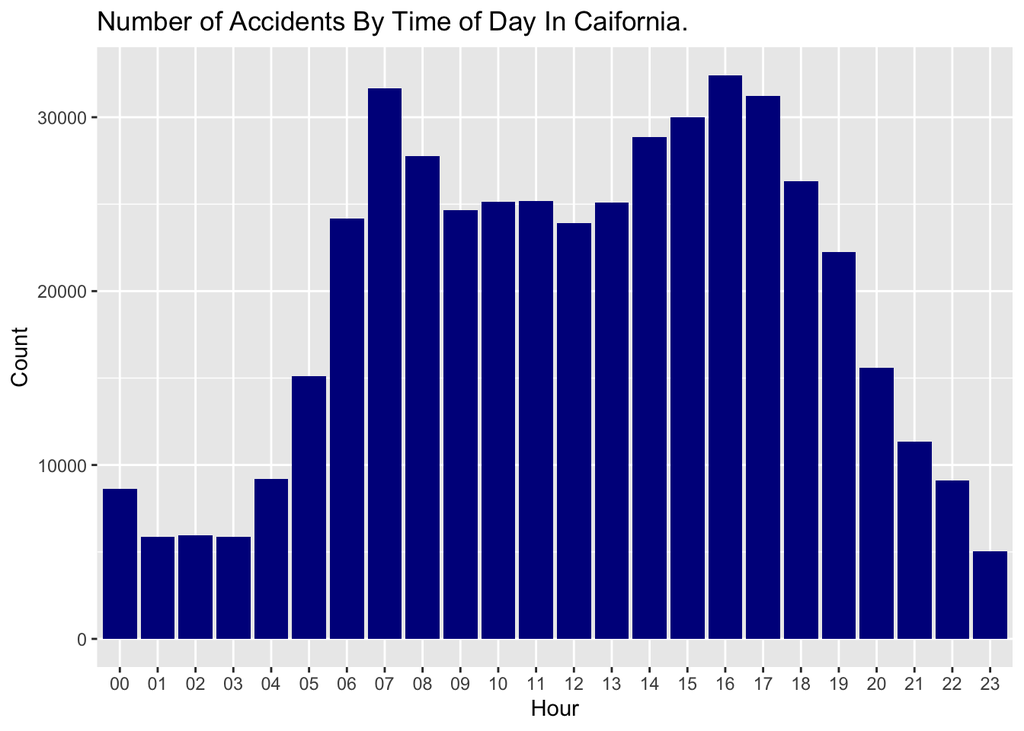

```r
california_accidents <- filter(accident_data, State == "CA")
# Grouped by state and counted the number of accidents in each state.
california_accident_by_hour <- california_accidents %>%
  filter(!is.na(Hour)) %>%
  group_by(Hour) %>%
  summarise(Count= n())
ggplot(data=(california_accident_by_hour), aes(x = Hour, y = Count)) +
  geom_bar(stat = "identity", fill = "darkblue") +
  ggtitle("Number of Accidents By Time of Day In Caifornia.")
```

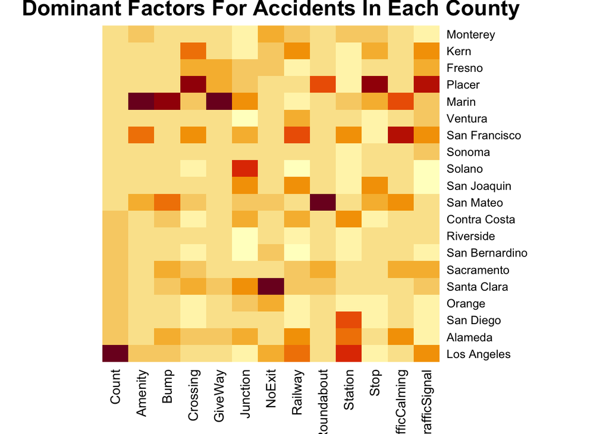

```r
california_accident_by_county <- california_accidents %>%
  group_by(County) %>%
  summarise(Count = n(), Amenity = mean(Amenity_bool), Bump = mean(Bump_bool), Crossing = mean(Crossing_bool),
            GiveWay = mean(GiveWay_bool), Junction = mean(Junction_bool), NoExit = mean(NoExit_bool),
            Railway = mean(Railway_bool), Roundabout = mean(Roundabout_bool), Station = mean(Station_bool),
            Stop = mean(Stop_bool), TrafficCalming = mean(TrafficCalming_bool), TrafficSignal = mean(TrafficSignal_bool)) %>%
  ungroup() %>%
  arrange(desc(Count)) %>%
  top_n(20, Count)
heat_matrix = as.matrix(california_accident_by_county[2:14])
row.names(heat_matrix) <- t(california_accident_by_county[1])
heatmap(heat_matrix, Rowv = NA, Colv = NA, scale = "column", main = "Dominant Factors For Accidents In Each County")
```